# Project 5

Lakshmi Mounica Marupeddi

2024-07-14

```r
library(dplyr)
library(tidyverse)
df = read_csv("athlete_events.csv")
df1 = df %>% distinct()
```

### Question 1

1. Read in the athlete_events.csv file. Get rid of the duplicated rows. How many rows and columns are there?

```r
glimpse(df1)
```

```
## Rows: 269,731
## Columns: 15
## $ ID     <dbl> 1, 2, 3, 4, 5, 5, 5, 5, 5, 5, 6, 6, 6, 6, 6, 6, 6, 6, 7, 7, 7, …
## $ Name   <chr> "A Dijiang", "A Lamusi", "Gunnar Nielsen Aaby", "Edgar Lindenau…
## $ Sex    <chr> "M", "M", "M", "M", "F", "F", "F", "F", "F", "F", "M", "M", "M"…
## $ Age    <dbl> 24, 23, 24, 34, 21, 21, 25, 25, 27, 27, 31, 31, 31, 31, 33, 33,…
## $ Height <dbl> 180, 170, NA, NA, 185, 185, 185, 185, 185, 185, 188, 188, 188, …
## $ Weight <dbl> 80, 60, NA, NA, 82, 82, 82, 82, 82, 82, 75, 75, 75, 75, 75, 75,…
## $ Team   <chr> "China", "China", "Denmark", "Denmark/Sweden", "Netherlands", "…
## $ NOC    <chr> "CHN", "CHN", "DEN", "DEN", "NED", "NED", "NED", "NED", "NED", …
## $ Games  <chr> "1992 Summer", "2012 Summer", "1920 Summer", "1900 Summer", "19…
## $ Year   <dbl> 1992, 2012, 1920, 1900, 1988, 1988, 1992, 1992, 1994, 1994, 199…
## $ Season <chr> "Summer", "Summer", "Summer", "Summer", "Winter", "Winter", "Wi…
## $ City   <chr> "Barcelona", "London", "Antwerpen", "Paris", "Calgary", "Calgar…
## $ Sport  <chr> "Basketball", "Judo", "Football", "Tug-Of-War", "Speed Skating"…
## $ Event  <chr> "Basketball Men's Basketball", "Judo Men's Extra-Lightweight", …
## $ Medal  <chr> NA, NA, NA, "Gold", NA, NA, NA, NA, NA, NA, NA, NA, NA, NA, NA,…
```

### Question 2

2. This dataset contains both summer and winter olympics.
   1. How many rows are there in the summer and how many are there in the winter olympics?
   2. Create a bar plot showing the number of entries in the summer and winter olympics.

```r
tempa = df1 %>% group_by(Season) %>% summarize(n = n())
tempa
```

```
## # A tibble: 2 × 2
##   Season      n
##   <chr>   <int>
## 1 Summer 221167
## 2 Winter  48564
```

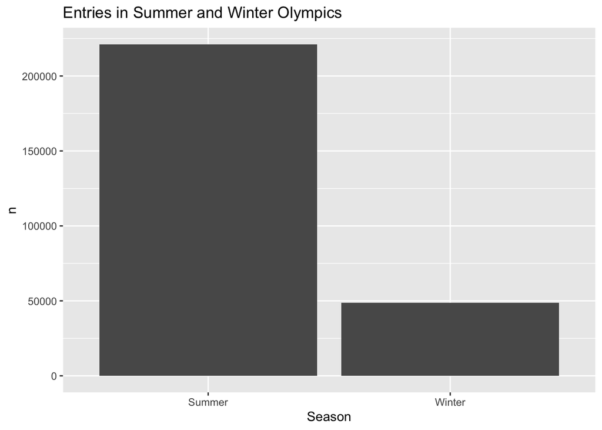

```r
tempa %>% ggplot(aes(x=Season, y=n)) + geom_col()  + ggtitle("Entries in Summer and Winter Olympics")
```

### Question 3 Count the number of unique athletes in the winter and summer olympics separately. (That is, within each season you will count each athlete only once.)  
a) How many unique athletes are there in the summer olympics?  
b) Create a bar chart for winter and summer olympics showing the number of unique athletes.

```r
tempb = df1 %>% group_by(Season, Name) %>% count()
tempb = tempb %>% group_by(Season) %>% summarize(n = n())
tempb
```

```
## # A tibble: 2 × 2
##   Season      n
##   <chr>   <int>
## 1 Summer 116121
## 2 Winter  18923
```

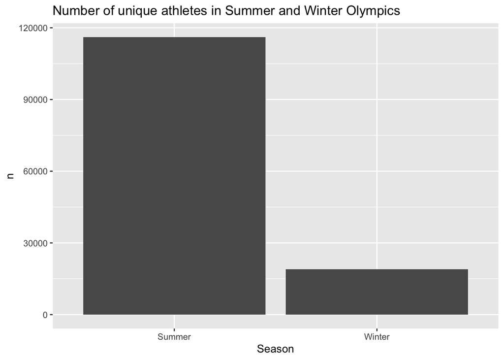

```r
tempb %>% ggplot(aes(x=Season, y=n)) + geom_col()  + ggtitle("Number of unique athletes in Summer and Winter Olympics")
```

### Question 4 Count the number of unique athletes from each country in the winter olympics.  
a) How many unique athletes are there from USA (NOC column) in the winter olympics?  
b) Create a bar plot showing the number of unique athletes in the winter olympics. Only include the top 10 countries.

```r
tempc = df1 %>% filter(Season=="Winter") %>% group_by(NOC, Name, Season) %>% summarize(n = n())
tempc = tempc %>% group_by(NOC) %>% summarize(n1=n()) %>% arrange(-n1) %>% head(10)
tempc
```

```
## # A tibble: 10 × 2
##    NOC      n1
##    <chr> <int>
##  1 USA    1697
##  2 CAN    1278
##  3 SUI    1006
##  4 ITA     935
##  5 SWE     902
##  6 GER     890
##  7 AUT     859
##  8 FRA     822
##  9 NOR     817
## 10 JPN     795
```

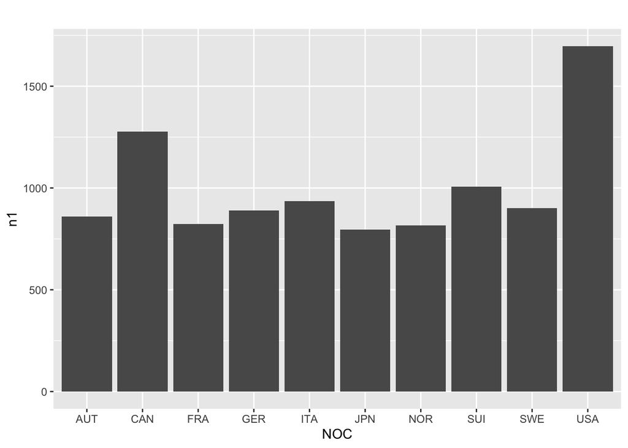

```r
tempc %>% ggplot(aes(x=NOC, y=n1)) + geom_col()  + ggtitle("")
```

### Question 5 We will create histograms of two countries.  
a) What is the average weight of Swedish and US athletes after accounting for each year and season? (meaning: you should take the unique athletes in each year and season) b) Create a histogram of the weights of Swedish athletes (NOC = SWE).  
c) Create a histogram of the weights of American athletes (NOC = USA).

```r
tempd = df1 %>% filter(NOC %in% c("SWE", "USA")) %>% distinct(Year, Season, Name, .keep_all = TRUE)
# Calculate average weight by year and season
tempd %>% group_by(NOC) %>% summarize(mean(Weight, na.rm = TRUE))
```

```
## # A tibble: 2 × 2
##   NOC   `mean(Weight, na.rm = TRUE)`
##   <chr>                        <dbl>
## 1 SWE                           74.8
## 2 USA                           74.5
```

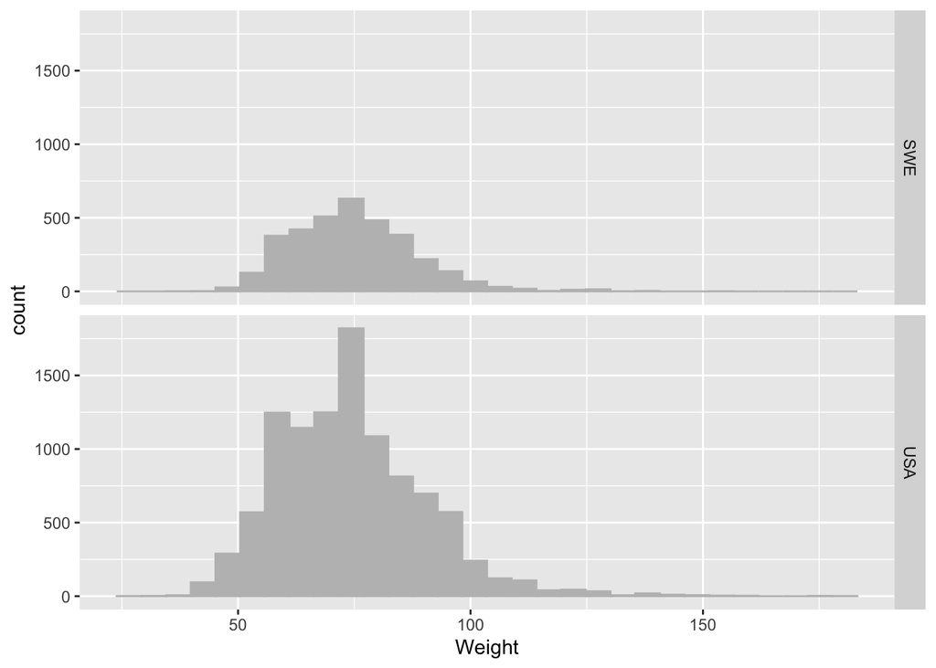

```r
# histograms
tempd %>% ggplot(aes(x = Weight)) + geom_histogram(fill = "grey", colour = "grey") +
  facet_grid(NOC ~ .)
```

### Question 6 We would like to check whether basketball players are taller than other athletes. We will focus on USA.

Compare the basketball, tennis, and wrestling players’ (Sport column) average and median heights from USA. Which sports athletes are tallest on average?

Create box plots of heights of athletes from USA playing basketball, tennis, and wrestling.

```r
tempe = df1 %>% filter(NOC=="USA")
sports = tempe %>% filter(Sport %in% c("Basketball", "Tennis", "Wrestling") )

# Which sports athletes are tallest on average?
#Ans: Basketball athletes are tallest on average at 192.6070
avgBB = sports %>% group_by(Sport) %>% summarize(mean = mean(Height, na.rm = TRUE), median = median(Height, na.rm = TRUE))
avgBB
```

```
## # A tibble: 3 × 3
##   Sport       mean median
##   <chr>      <dbl>  <dbl>
## 1 Basketball  193.    193
## 2 Tennis      182.    183
## 3 Wrestling   174.    173
```

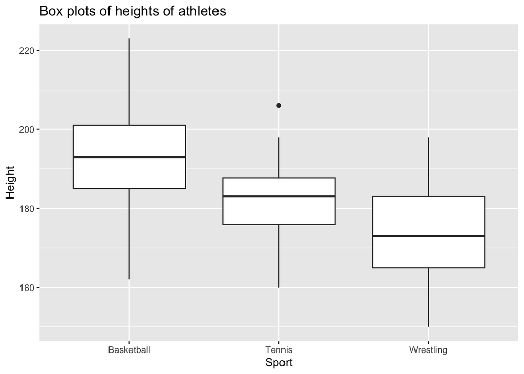

```r
# boxplots
sports %>% ggplot(aes(x=Sport, y = Height)) + geom_boxplot() + ggtitle("Box plots of heights of athletes")
```

### Question 7 We would like to check whether US volleyball players’ average height has changed over the years.